# Binomial Mixture and Alternate Binomial Distributions PMF values

## Probability Mass Function values for McDonald Generalized Beta-Binomial Distribution

McDonald Generalized Beta-Binomial Distribution is quite similar to GHGBB distribution only that it does not have any use of the Gaussian hyper-geometric function. Still it includes three shape parameters which are a,b and c. With necessary small twists in shape parameters it is possible to produce very vivid pmf values. Below are few plots explaining those scenarios.

- a,b,c are in the domain region of above zero.

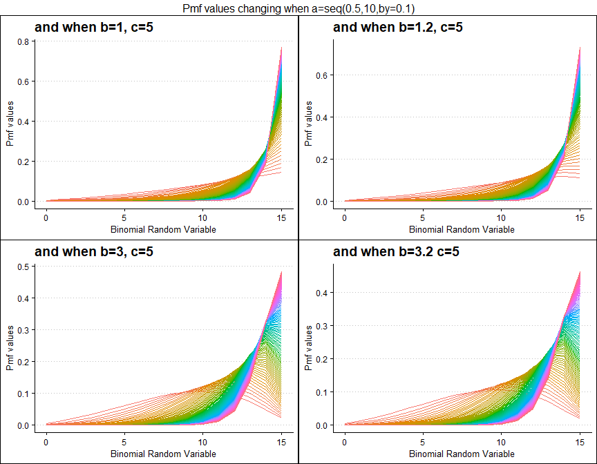

```r
  b1c5 <- dMcGBBplot(a=seq(.5,10,by=.1),b=1,c=5,
                 plot_title="and when b=1, c=5",a_seq=T,b_seq=F)
b1.2c5 <- dMcGBBplot(a=seq(.5,10,by=.1),b=1.2,c=5,
                   plot_title="and when b=1.2, c=5",a_seq=T,b_seq=F)
  b3c5 <- dMcGBBplot(a=seq(.5,10,by=.1),b=3,c=5,
                 plot_title="and when b=3, c=5",a_seq=T,b_seq=F)
b3.2c5 <- dMcGBBplot(a=seq(.5,10,by=.1),b=3.2,c=5,
                   plot_title="and when b=3.2 c=5",a_seq=T,b_seq=F)

grid.arrange(b1c5,b1.2c5,b3c5,b3.2c5,nrow=2,
             top="Pmf values changing when a=seq(0.5,10,by=0.1)")
```

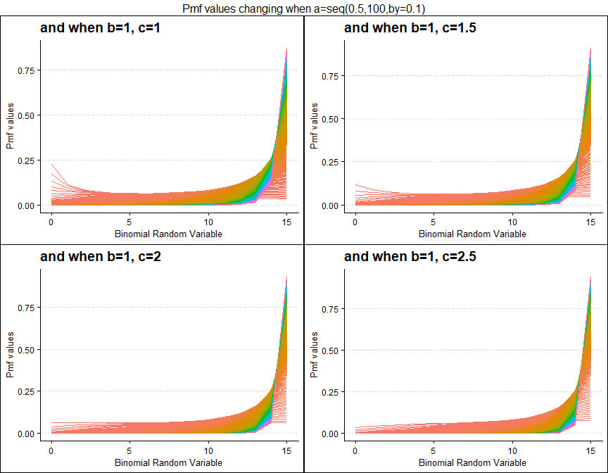

```r
  b1c1 <- dMcGBBplot(a=seq(.5,100,by=.1),b=1,c=1,
                 plot_title="and when b=1, c=1",a_seq=T,b_seq=F)
b1c1.5 <- dMcGBBplot(a=seq(.5,100,by=.1),b=1,c=1.5,
                   plot_title="and when b=1, c=1.5",a_seq=T,b_seq=F)
  b1c2 <- dMcGBBplot(a=seq(.5,100,by=.1),b=1,c=2,
                 plot_title="and when b=1, c=2",a_seq=T,b_seq=F)
b1c2.5 <- dMcGBBplot(a=seq(.5,100,by=.1),b=1,c=2.5,
                   plot_title="and when b=1, c=2.5",a_seq=T,b_seq=F)

grid.arrange(b1c1,b1c1.5,b1c2,b1c2.5,nrow=2,
             top="Pmf values changing when a=seq(0.5,100,by=0.1)")
```

## Probability Mass Function values for Gamma Binomial Distribution

Gamma Binomial Distribution has two shape parameters which influence the pmf values. They are namely a and b. These two parameters are inherited from the Gamma distribution when mixing it to the Binomial Distribution. Pmf values are plotted below according to a and b values change

- a,b are in the domain region of above zero.

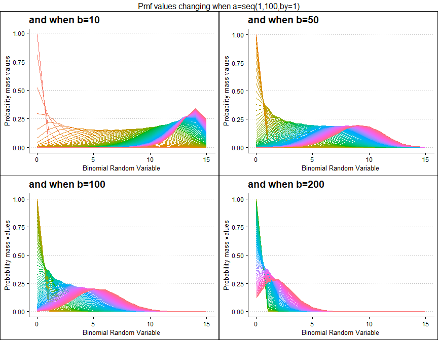

```r
 b10 <- dGammaBinplot(a=seq(1,100,by=1),b=10,plot_title="and when b=10",a_seq= T)
 b50 <- dGammaBinplot(a=seq(1,100,by=1),b=50,plot_title="and when b=50",a_seq= T)
b100 <- dGammaBinplot(a=seq(1,100,by=1),b=100,plot_title="and when b=100",a_seq= T)
b200 <- dGammaBinplot(a=seq(1,100,by=1),b=200,plot_title="and when b=200",a_seq= T)

grid.arrange(b10,b50,b100,b200,nrow=2,top="Pmf values changing when a=seq(1,100,by=1)")
```

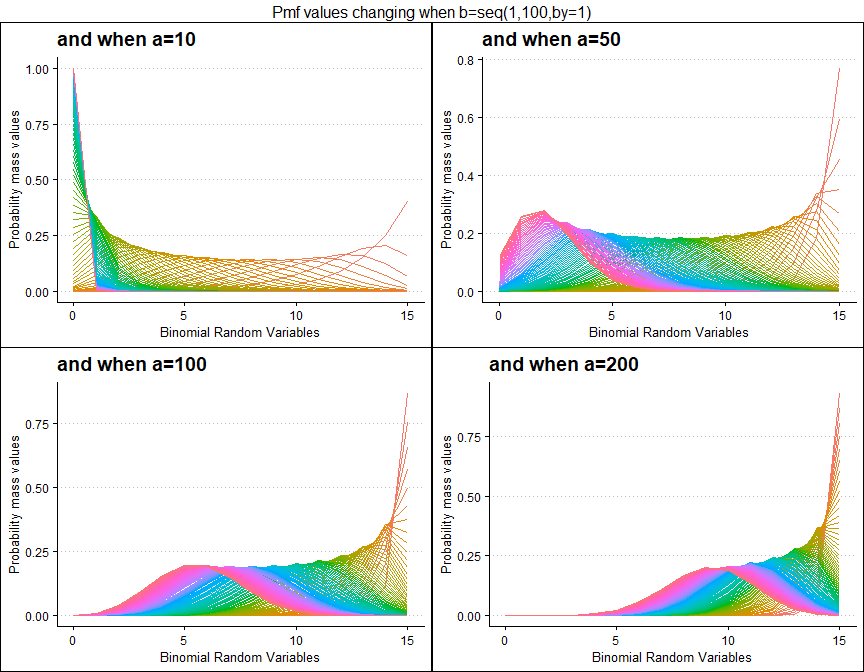

```r
 a10 <- dGammaBinplot(b=seq(1,100,by=1),a=10,plot_title="and when a=10",a_seq= F)
 a50 <- dGammaBinplot(b=seq(1,100,by=1),a=50,plot_title="and when a=50",a_seq= F)
a100 <- dGammaBinplot(b=seq(1,100,by=1),a=100,plot_title="and when a=100",a_seq= F)
a200 <- dGammaBinplot(b=seq(1,100,by=1),a=200,plot_title="and when a=200",a_seq= F)

grid.arrange(a10,a50,a100,a200,nrow=2,top="Pmf values changing when b=seq(1,100,by=1)")
```

## Probability Mass Function values for Grassia II Binomial Distribution

Grassia Binomial Distribution has two shape parameters which influence the pmf values. They are namely a and b. Pmf values are plotted below according to a and b values change

- a,b are in the domain region of above zero.

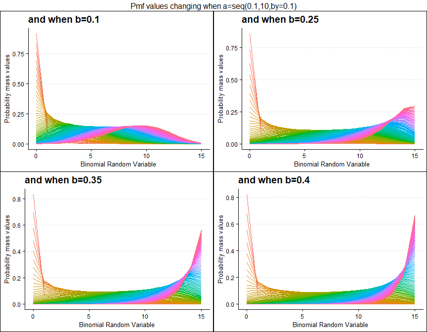

```r
 b1 <- dGrassiaIIBinplot(a=seq(0.1,10,by=0.1),b=0.1,plot_title="and when b=0.1",a_seq= T)
b25 <- dGrassiaIIBinplot(a=seq(0.1,10,by=0.1),b=0.25,plot_title="and when b=0.25",a_seq= T)
b35 <- dGrassiaIIBinplot(a=seq(0.1,10,by=0.1),b=0.35,plot_title="and when b=0.35",a_seq= T)
b40 <- dGrassiaIIBinplot(a=seq(0.1,10,by=0.1),b=0.4,plot_title="and when b=0.4",a_seq= T)

grid.arrange(b1,b25,b35,b40,nrow=2,top="Pmf values changing when a=seq(0.1,10,by=0.1)")
```

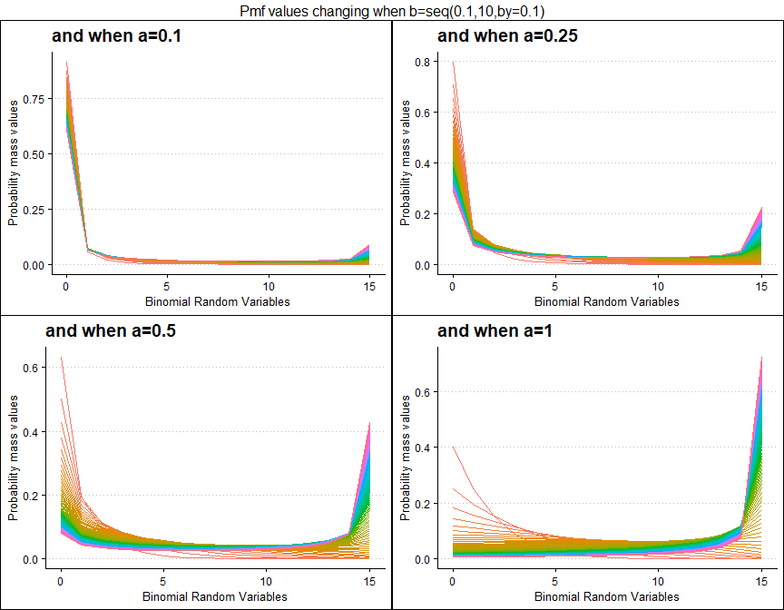

```r
 a1 <- dGrassiaIIBinplot(b=seq(0.1,10,by=0.1),a=0.1,plot_title="and when a=0.1",a_seq= F)
a25 <- dGrassiaIIBinplot(b=seq(0.1,10,by=0.1),a=0.25,plot_title="and when a=0.25",a_seq= F)
 a5 <- dGrassiaIIBinplot(b=seq(0.1,10,by=0.1),a=0.5,plot_title="and when a=0.5",a_seq= F)
a10 <- dGrassiaIIBinplot(b=seq(0.1,10,by=0.1),a=1,plot_title="and when a=1",a_seq= F)

grid.arrange(a1,a25,a5,a10,nrow=2,top="Pmf values changing when b=seq(0.1,10,by=0.1)")
```

# Alternate Binomial Distributions

Alternate Binomial Distributions were developed for the purpose of replacing Binomial Distribution. These distributions are similar to Binomial distribution but with special parameters which try to explain the over dispersion. Using pmf values it is possible to understand how much variation they can achieve as probability values generated. The functions which can develop pmf values for Alternate Binomial Distributions are

- `dAddBin` - producing pmf values primarily for Additive Binomial Distribution.
- `dBetaCorrBin` - producing pmf values primarily for Beta-Correlated Binomial Distribution.
- `dCOMPBin` - producing pmf values primarily for COM Poisson Binomial Distribution.
- `dCorrBin` - producing pmf values primarily for Correlated Binomial Distribution.
- `dMultiBin` - producing pmf values primarily for Multiplicative Binomial Distribution.
- `dLMBin` - producing pmf values primarily for Lovinson Multiplicative Binomial Distribution.

Specific functions were created for the purpose of making plot construction easy when there are more than two parameters involved. These functions are namely

- `dAddBinplot` - plot function to Additive Binomial Distribution.
- `dBetaCorrBinplot` - plot function to Beta Correlated Binomial Distribution.
- `dCOMPBinplot` - plot function to COM Poisson Binomial Distribution.
- `dCorrBinplot` - plot function to Correlated Binomial Distribution.
- `dMultiBinplot` - plot function to Multiplicative Binomial Distribution.
- `dLMBinplot` - producing pmf values primarily for Lovinson Multiplicative Binomial Distribution.

## Probability Mass Function values for Additive Binomial Distribution

Additive Binomial distribution has one special parameter , which is the alpha value. Other than that it is included with a probability value. It is a replace for Binomial Distribution. Below is the plot generated to understand how its pmf values change.

- p value in-between zero and one.
- alpha value in-between negative one and positive one.

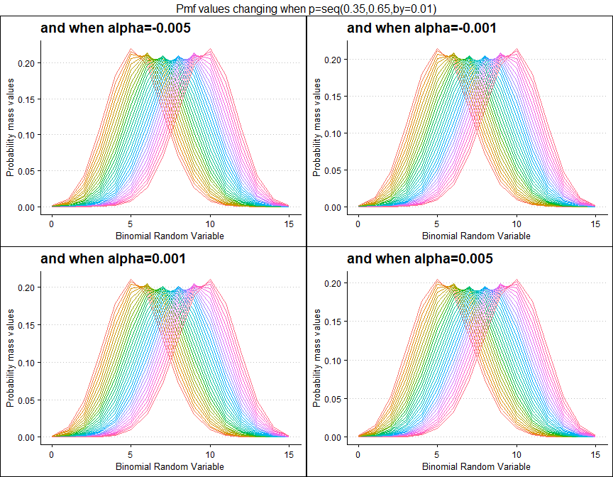

```r
 alpha.005 <- dAddBinplot(p=seq(0.35,0.65,by=0.01),alpha=-0.005,
                       plot_title="and when alpha=-0.005",p_seq= T)
 alpha.001 <- dAddBinplot(p=seq(0.35,0.65,by=0.01),alpha=-0.001,
                       plot_title="and when alpha=-0.001",p_seq= T)
alpha0.001 <- dAddBinplot(p=seq(0.35,0.65,by=0.01),alpha=0.001,
                        plot_title="and when alpha=0.001",p_seq= T)
alpha0.005 <- dAddBinplot(p=seq(0.35,0.65,by=0.01),alpha=0.005,
                        plot_title="and when alpha=0.005",p_seq= T)

grid.arrange(alpha.005,alpha.001,alpha0.001,alpha0.005,nrow=2,
             top="Pmf values changing when p=seq(0.35,0.65,by=0.01)")
```

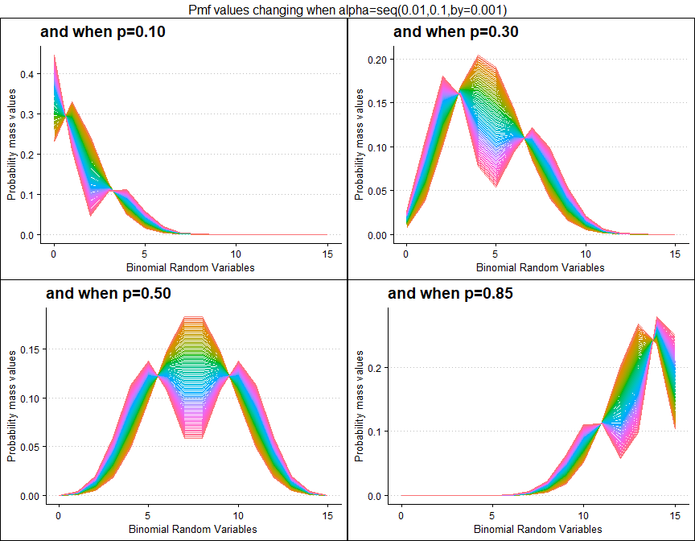

```r
p.10 <- dAddBinplot(alpha=seq(.01,.1,by=0.001),p=0.1,
                  plot_title="and when p=0.10",p_seq= F)
p.30 <- dAddBinplot(alpha=seq(.01,.1,by=0.001),p=0.3,
                  plot_title="and when p=0.30",p_seq= F)
p.50 <- dAddBinplot(alpha=seq(.01,.1,by=0.001),p=0.5,
                  plot_title="and when p=0.50",p_seq= F)
p.85 <- dAddBinplot(alpha=seq(.01,.1,by=0.001),p=0.85,
                  plot_title="and when p=0.85",p_seq= F)

grid.arrange(p.10,p.30,p.50,p.85,nrow=2,
             top="Pmf values changing when alpha=seq(0.01,0.1,by=0.001)")
```

## Probability Mass Function values for Beta-Correlated Binomial Distribution

Beta-Correlated Binomial distribution has three parameters in concern, where cov is the covariance from Correlated distribution and a,b are from the Beta Distribution. Mixing Binomial, Beta and Correlated distributions only we can develop the Beta-Correlated Binomial distribution. Below is the plot of explaining how their Pmf values change with respective to cov, a and b parameters.

- cov is the covariance value in between negative infinity and positive infinity.
- a, b are in the domain region of above zero.

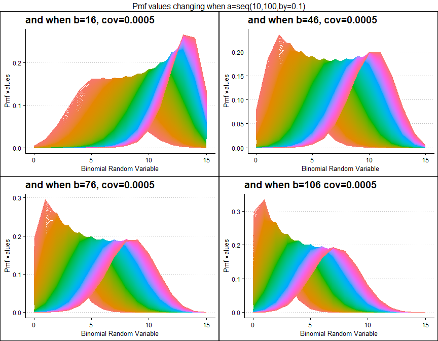

```r
 b16cov5 <- dBetaCorrBinplot(a=seq(10,100,by=0.1),b=16,cov=0.0005,
                 plot_title="and when b=16, cov=0.0005",a_seq=T,b_seq=F)
 b46cov5 <- dBetaCorrBinplot(a=seq(10,100,by=0.1),b=46,cov=0.0005,
                   plot_title="and when b=46, cov=0.0005",a_seq=T,b_seq=F)
 b76cov5 <- dBetaCorrBinplot(a=seq(10,100,by=0.1),b=76,cov=0.0005,
                 plot_title="and when b=76, cov=0.0005",a_seq=T,b_seq=F)
b106cov5 <- dBetaCorrBinplot(a=seq(10,100,by=0.1),b=106,cov=0.0005,
                   plot_title="and when b=106 cov=0.0005",a_seq=T,b_seq=F)

grid.arrange(b16cov5,b46cov5,b76cov5,b106cov5,nrow=2,
             top="Pmf values changing when a=seq(10,100,by=0.1)")
```

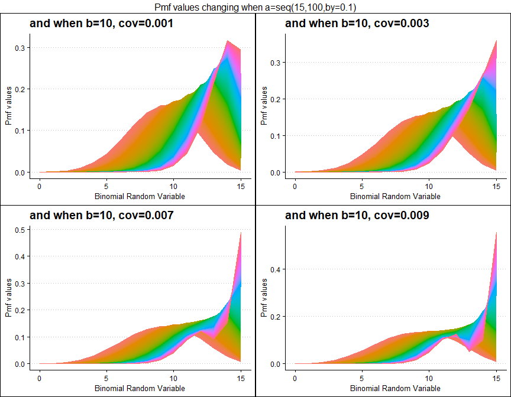

```r
b10cov1 <- dBetaCorrBinplot(a=seq(15,100,by=0.1),b=10,cov=0.001,
                 plot_title="and when b=10, cov=0.001",a_seq=T,b_seq=F)
b10cov3 <- dBetaCorrBinplot(a=seq(15,100,by=0.1),b=10,cov=0.003,
                   plot_title="and when b=10, cov=0.003",a_seq=T,b_seq=F)
b10cov7 <- dBetaCorrBinplot(a=seq(15,100,by=0.1),b=10,cov=0.007,
                 plot_title="and when b=10, cov=0.007",a_seq=T,b_seq=F)
b10cov9 <- dBetaCorrBinplot(a=seq(15,100,by=0.1),b=10,cov=0.009,
                   plot_title="and when b=10, cov=0.009",a_seq=T,b_seq=F)

grid.arrange(b10cov1,b10cov3,b10cov7,b10cov9,nrow=2,
             top="Pmf values changing when a=seq(15,100,by=0.1)")
```